# Problem Set #3

2022-10-03

```r
# setwd('/Users/billyge/Desktop/Emory Fall 2022/QTM
# 385-4/problem sets/ps github/ps3')
# setwd('/Users/annie/Desktop/QTM385/QTM350_Github/QTM350
# Github/QTM385/ps3')
rm(list = ls())
c_test <- read.csv("college_test.csv")
c_train <- read.csv("college_train.csv")
o_test <- read.csv("office_test.csv")
o_train <- read.csv("office_train.csv")
```

This is the third problem set for QTM 385 - Intro to Statistical Learning. This homework will cover applied exercises related to predictor selection for linear regression models.

Please use the intro to RMarkdown posted in the Intro module and my .Rmd file as a guide for writing up your answers. You can use any language you want, but I think that a number of the computational problems are easier in R. Please post any questions about the content of this problem set or RMarkdown questions to the corresponding discussion board.

Your final deliverable should be two files: 1) a .Rmd/.ipynb file and 2) either a rendered HTML file or a PDF. Students can complete this assignment in groups of up to 3. Please identify your collaborators at the top of your document. All students should turn in a copy of the solutions, but your solutions can be identical to those of your collaborators.

This assignment is due by October 3rd, 2022 at 11:59 PM EST.

Collaborators: Billy Ge, Latifa Tan, Annie Luo

## Problem 1: An Important Ridge and LASSO Identity (15 pts)

Both Ridge and LASSO present **regularized** solutions to the ill-posed variable selection problem for the linear model. Recall that we can view each of these metthods as approaches to estimating coefficients that minimize different loss functions:

$$\hat{\boldsymbol \beta}_{OLS} =
\underset{\boldsymbol \beta}{\text{argmin }} (\boldsymbol y - \mathbf X
\boldsymbol \beta)'(\boldsymbol y - \mathbf X \boldsymbol
\beta)$$

$$\hat{\boldsymbol \beta}_{Ridge} =
\underset{\boldsymbol \beta}{\text{argmin }} (\boldsymbol y - \mathbf X
\boldsymbol \beta)'(\boldsymbol y - \mathbf X \boldsymbol \beta) +
\sum \limits_{j = 1}^P \beta_j^2$$

$$\hat{\boldsymbol \beta}_{LASSO} =
\underset{\boldsymbol \beta}{\text{argmin }} (\boldsymbol y - \mathbf X
\boldsymbol \beta)'(\boldsymbol y - \mathbf X \boldsymbol \beta) +
\sum \limits_{j = 1}^P |\beta_j|$$

There is a relationship between the optimal solutions for the regression coefficients under no penalty (the OLS solution), the ridge penalty, and the LASSO penalty. The exact relationship cannot be derived for most cases, but we can gain some knowledge by assuming that the predictors are exactly orthogonal to one another. Since we can always rescale the variance of the features, we can further restrict this to feature sets that have **orthonormal** columns - $\boldsymbol{X'X} = \mathcal{I}_P$.

Assuming the feature matrix, $\boldsymbol{X}$, has orthnormal columns, show that:

$$\hat{\beta}_{OLS} = \boldsymbol{X'y}
\text{ ; } \hat{\beta}_{Ridge} = \frac{\hat{\beta}_{OLS}}{1 +
\lambda} \text{ ; } \hat{\beta}_{LASSO} =
\text{sign}(\hat{\beta}_{OLS}) \times \text{max}(|\hat{\beta}_{OLS}| -
\lambda , 0)$$

What do these equations show about **how** ridge and LASSO shrink coefficients towards zero? Why can the LASSO set a coefficient to zero while ridge cannot?

Notes:

1. $\sum \limits_{j = 1}^P \beta_j^2$ can also be expressed as $\beta'\beta$.
2. Substitute $\hat{\beta}_{OLS} = \boldsymbol{X'y}$ whenever possible.
3. It is probably easier to drop everything to elements of the coefficient vector for the LASSO at a certain point - e.g. work with $\beta_j$ instead of $\boldsymbol{\beta}$. Since everything becomes a sum or sum of squares or sum of absolute values, you can separate the problem out easier this way.
4. You can take it as a given that the sign of $\hat{\beta}_{OLS,j}$ is the same as $\hat{\beta}_{LASSO,j}$ (unless the LASSO solution is zero, but it won’t matter there).
5. These solutions can be found online and in various textbook resources. I think this is a great exercise for thinking through complex minimization problems, so don’t spoil yourself unless you really find yourself stuck.

## Problem 1 solution:

OLS:
$$\begin{eqnarray}
\frac{\partial \left[ \left(\boldsymbol{y} -
\boldsymbol{X}\boldsymbol{\beta} \right)' \left(\boldsymbol{y} -
\boldsymbol{X}\boldsymbol{\beta} \right) \right]}{\partial
\boldsymbol{\beta}} &=& 0\\
(-2) \boldsymbol{X}' \left(\boldsymbol{y} -
\boldsymbol{X}\boldsymbol{\beta} \right) &=& 0\\
\boldsymbol{X}'\boldsymbol{y} -
\boldsymbol{X}'\boldsymbol{X}\boldsymbol{\beta} &=& 0\\
\boldsymbol{\hat{\beta}_{OLS}} &=&
\left(\boldsymbol{X}'\boldsymbol{X}
\right)^{-1}\boldsymbol{X}'\boldsymbol{y}\\
\end{eqnarray}$$
Since we are assuming orthonormal columns, we plug in $\boldsymbol{X'X} = \mathcal{I}_P$
$$\begin{eqnarray}
\boldsymbol{\hat{\beta}_{OLS}} &=& \left(\mathcal{I}_P
\right)^{-1}\boldsymbol{X}'\boldsymbol{y}\\
\boldsymbol{\hat{\beta}_{OLS}} &=&
\boldsymbol{X}'\boldsymbol{y}
\end{eqnarray}$$
Ridge:
$$\begin{eqnarray}
\frac{\partial \left[ \left(\boldsymbol{y} -
\boldsymbol{X}\boldsymbol{\beta} \right)' \left(\boldsymbol{y} -
\boldsymbol{X}\boldsymbol{\beta} \right) + \lambda\sum \limits_{j =
1}^P \beta_j^2 \right]}{\partial \boldsymbol{\beta}} &=& 0\\
(-2) \boldsymbol{X}' \left(\boldsymbol{y} -
\boldsymbol{X}\boldsymbol{\beta} \right) + 2\lambda\boldsymbol{\beta}
&=& 0\\
\lambda\boldsymbol{\beta} &=& \boldsymbol{X}'\boldsymbol{y}
- \boldsymbol{X}'\boldsymbol{X}\boldsymbol{\beta}
\end{eqnarray}$$
Plug in $\boldsymbol{X'X} = \mathcal{I}_P$ and $\boldsymbol{\hat{\beta}_{OLS}} = \boldsymbol{X}'\boldsymbol{y}$, we get
$$\begin{eqnarray}
\lambda\boldsymbol{\beta} &=& \boldsymbol{\hat{\beta}_{OLS}} -
\mathcal{I}_P\boldsymbol{\beta}\\
\lambda\boldsymbol{\beta}+\boldsymbol{\beta} &=&
\boldsymbol{\hat{\beta}_{OLS}}\\
\boldsymbol{\hat{\beta}_{Ridge}} &=&
\frac{\boldsymbol{\hat{\beta}_{OLS}}}{1+\lambda}
\end{eqnarray}$$
LASSO: For each $\beta_j$:
$$\begin{eqnarray}
\hat{\beta}_{j,LASSO} &=& \underset{\boldsymbol
\beta_j}{\text{argmin }} (y_j - \mathbf x_j \beta_j)^2 + \lambda *
|\beta_j|\\
\frac{\partial \left[ \hat{\beta}_{j,LASSO} \right]}{\partial {\beta_j}}
&=& 2\left( -\boldsymbol x_j \right)'\left(y_j-\boldsymbol
{x_j} \beta_j \right)+\lambda * \text{sign} \left(\beta_j \right) = 0\\
\lambda * \text{sign} \left(\beta_j \right) &=&
2\boldsymbol{x_j}'y_j-2\boldsymbol {x_j}'\boldsymbol {x_j}
\beta_j
\end{eqnarray}$$
Plug in $\boldsymbol{x_j'x_j} = \mathcal{I}_1$ and ${\hat{\beta}_{j,OLS}} = \boldsymbol{x_j}'{y_j}$, we get
$$\begin{eqnarray}
\lambda * \text{sign} \left(\beta_j \right) &=&
2\hat{\beta}_{j,OLS}-2\mathcal{I}_1 \beta_j\\
\beta_j &=& \hat{\beta}_{j,OLS} - \frac{\lambda}{2}\text{sign}
\left(\beta_j \right)
\end{eqnarray}$$
Set constant $\lambda$ to be $\frac{\lambda}{2}$, and summing up $\beta_j$, we get
$$\begin{eqnarray}
\hat {\boldsymbol \beta}_{LASSO} &=&
\hat{\boldsymbol{\beta}}_{OLS} - \lambda*\text{sign} \left(\beta_j
\right)
\end{eqnarray}$$
When $\hat{\boldsymbol{\beta}}_{OLS} > 0$, $\hat {\boldsymbol \beta}_{LASSO} = \hat{\boldsymbol{\beta}}_{OLS} - \lambda$; when $\hat{\boldsymbol{\beta}}_{OLS} < 0$, $\hat {\boldsymbol \beta}_{LASSO} = \hat{\boldsymbol{\beta}}_{OLS} + \lambda$. Therefore, we get
$$\begin{eqnarray}
\hat {\boldsymbol \beta}_{LASSO} &=& \text{sign}
\left(\hat{\boldsymbol{\beta}}_{OLS} \right) *
\left(|\hat{\boldsymbol{\beta}}_{OLS}| - \lambda \right)
\end{eqnarray}$$

Ridge shrinks coefficients toward 0 because as $\lambda$ increases, the denominator increases and thus $\boldsymbol{\hat{\beta}_{Ridge}}$ decreases. However, unless $\lambda$ goes to infinity, increasing the denominator can never shrink the fraction into exactly 0. LASSO shrinks coefficients toward 0 because as $\lambda$ increases to a value that is equal to $|\hat{\boldsymbol{\beta}}_{OLS}|$, $\hat {\boldsymbol \beta}_{LASSO}$ goes to 0. LASSO coefficients can reach exactly 0 because it’s possible for $\lambda$ to be exactly $|\hat{\boldsymbol{\beta}}_{OLS}|$.

## Problem 2: Applying Ridge and LASSO (35 pts)

Ridge and LASSO are great methods for parsing through data sets with lots of predictors to find:

1. An interpretable set of important predictors - which predictors are **signal** and which ones are just **noise**
2. The set of parameters that minimize expected prediction error (with all the caveats that we discussed in the previous lectures)

Where these methods really shine for purpose 1 (and purpose 2, by construction) is when the ratio of predictors to observations approaches 1. To see this and work through an example using pre-built software, let’s try to build a model that predicts IMDB ratings for episodes of the Office (the U.S. Version). `office_train.csv` includes IMDB ratings (`imdb_rating`) for 115 episodes of the office and a number of predictors for each episode:

1. The season of the episode (1 - 9, which should be treated as an unordered categorical variable)
2. The number of times main characters speak in the episode (`andy` through `jan`)
3. The director of the episode (`ken_kwapis` through `justin_spitzer`) already “dummied out” so that a 1 means the person directed the episode and a 0 means they did not

Let’s use this data to build a predictive model for IMDB ratings and check our predictive accuracy on the heldout test set (`office_test.csv`).

For this problem, you can restrict your search to the set of standard linear models (e.g. no interactions, no basis expansions, etc.). If you would like to try to include more terms to improve the model, you are more than welcome to try!

**An important step: Get rid of any features that are observation specific!**

### Part 1 (10 pts)

Start by limiting yourself to the standard OLS model.

Find the regression coefficients that minimize the training error under squared error loss and use this model to compute the LOOCV estimate of the expected prediction error using all features.

Create a plot that demonstrates the regression coefficients granted by OLS. Which predictors are important? Which ones are not? I recommend using a sideways bar plot - you can see an example construction [here](https://dk81.github.io/dkmathstats_site/rvisual-sideways-bargraph.html).

Select a subset of “important” predictors and find the set of coefficients that minimizes MSE under squared error loss. Compute the LOOCV estimate of the expected prediction error for your smaller model. How does this LOOCV estimate compare to the LOOCV for the full model?

Note: You don’t need to try to perform any methods of subset selection in this step. Just use heuristic methods to determine which coefficients appear to be important for the model!

### Part 1 solution:

```r
# delete variable episode_name
o_train <- o_train %>%
    select(-episode_name)

# split variable season into 9 variables
dummy_o_train <- caret::dummyVars("~.", data = o_train)
o_train <- data.frame(predict(dummy_o_train, newdata = o_train))

# full model
p2p1_m <- lm(imdb_rating ~ ., data = o_train)

# LOOCV
lm_pred_metrics <- function(fit_model) {
    LOOCV <- mean((fit_model$residuals/(1 - hatvalues(fit_model)))^2)
    return(LOOCV)
}
lm_pred_metrics(p2p1_m)  #LOOCV is 0.2343854
```

```
## [1] 0.2343854
```

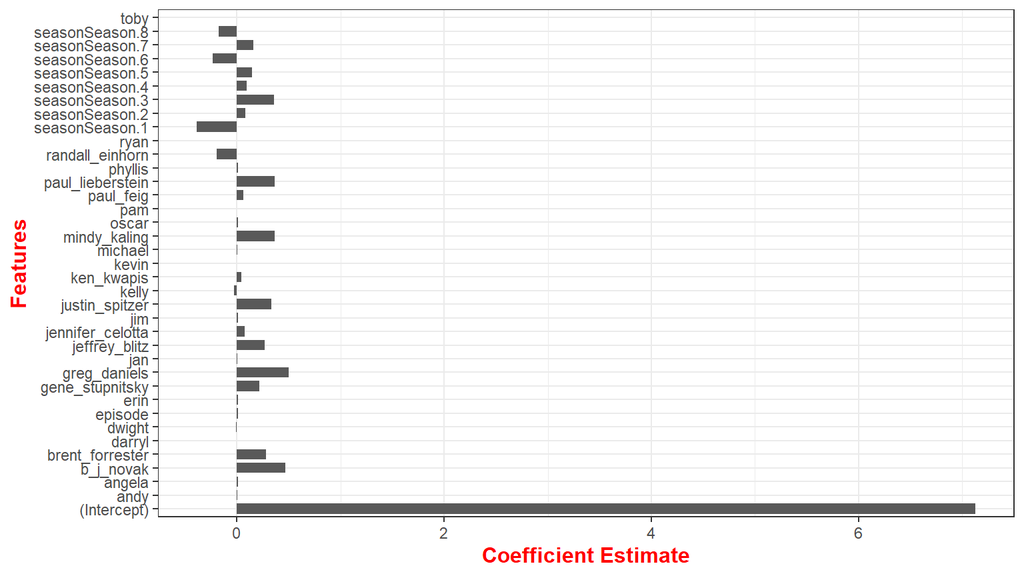

```r
# plot
cf <- coef(summary(p2p1_m, complete = TRUE))
cf <- data.frame(rownames(cf), cf)

ggplot(data = cf, aes(x = rownames.cf., y = Estimate)) + geom_bar(stat = "identity",
    width = 0.75) + coord_flip() + labs(x = "Features", y = "Coefficient Estimate") +
    theme_bw() + theme(plot.title = element_text(hjust = 0.5),
    axis.title.x = element_text(face = "bold", colour = "red",
        size = 12), axis.title.y = element_text(face = "bold",
        colour = "red", size = 12))
```

From the plot, we see that predictors season3, season1, paul_lieberstein, mindy_kaling, justin_spitzer, greg_daniels, and b_j_novak seem important, while the rest don’t.

```r
# subset of important predictors
p2p1_imp_pred <- o_train %>%
    select(seasonSeason.3, seasonSeason.1, paul_lieberstein,
        mindy_kaling, justin_spitzer, greg_daniels, b_j_novak,
        imdb_rating)

# important predictors model
p2p1_imp_pred_m <- lm(imdb_rating ~ ., data = p2p1_imp_pred)

# LOOCV
lm_pred_metrics(p2p1_imp_pred_m)  #LOOCV is 0.2543553
```

```
## [1] 0.2543553
```

The LOOCV of the important predictors model is slightly larger than the full model.

### Part 2 (10 pts)

Now, consider ridge regression. Using a pre-built implementation of ridge regression, train the model using a large number of possible values for $\lambda$.

Using $10$-fold cross validation, find a reasonable value of $\lambda$ that should minimize the expected prediction error. You can choose the actual minimum or a slightly less complex model. Defend this choice.

Create a plot that demonstrates the regression coefficients for the ridge regression with your optimal choice of $\lambda$. Which predictors are important? Which ones are not? I recommend using a sideways bar plot - you can see an example construction [here](https://dk81.github.io/dkmathstats_site/rvisual-sideways-bargraph.html).

### Part 2 solution:

```r
p2p2_pred <- data.matrix(o_train[, -38])
p2p2_out <- data.matrix(o_train$imdb_rating)

# 100 possible values of lambda
p2p2_ridgem <- glmnet(x = p2p2_pred, y = p2p2_out, family = "gaussian",
    alpha = 0, nlambda = 100)
print(p2p2_ridgem)
```

```
##
## Call:  glmnet(x = p2p2_pred, y = p2p2_out, family = "gaussian", alpha = 0,      nlambda = 100)
##
##     Df  %Dev  Lambda
## 1   37  0.00 195.800
## 2   37  0.54 178.400
## 3   37  0.59 162.600
## 4   37  0.64 148.100
## 5   37  0.71 135.000
## 6   37  0.77 123.000
## 7   37  0.85 112.000
## 8   37  0.93 102.100
## 9   37  1.02  93.020
## 10  37  1.11  84.760
## 11  37  1.22  77.230
```

[output cut: 89 more lines]

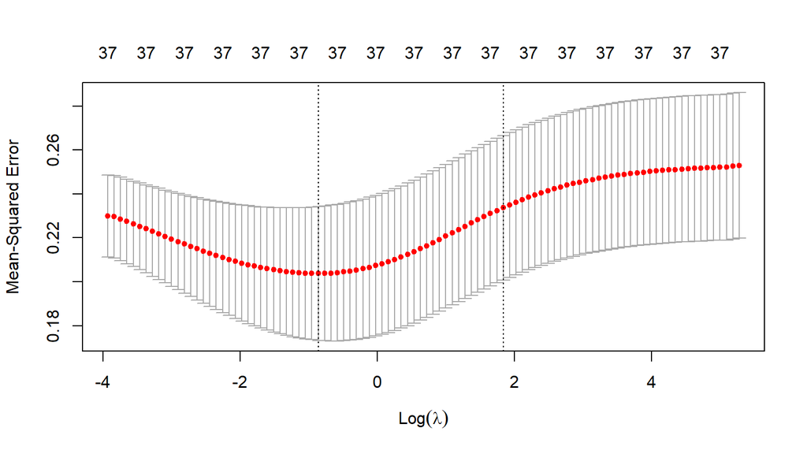

```r
p2p2_cv_ridgem <- cv.glmnet(x = p2p2_pred, y = p2p2_out, family = "gaussian",
    alpha = 0, nfolds = 10, type.measure = "mse")
plot(p2p2_cv_ridgem)
```

```r
print(p2p2_cv_ridgem)
```

```
##
## Call:  cv.glmnet(x = p2p2_pred, y = p2p2_out, type.measure = "mse",      nfolds = 10, family = "gaussian", alpha = 0)
##
## Measure: Mean-Squared Error
##
##     Lambda Index Measure      SE Nonzero
## min  0.422    67  0.2037 0.03047      37
## 1se  6.264    38  0.2337 0.03296      37
```

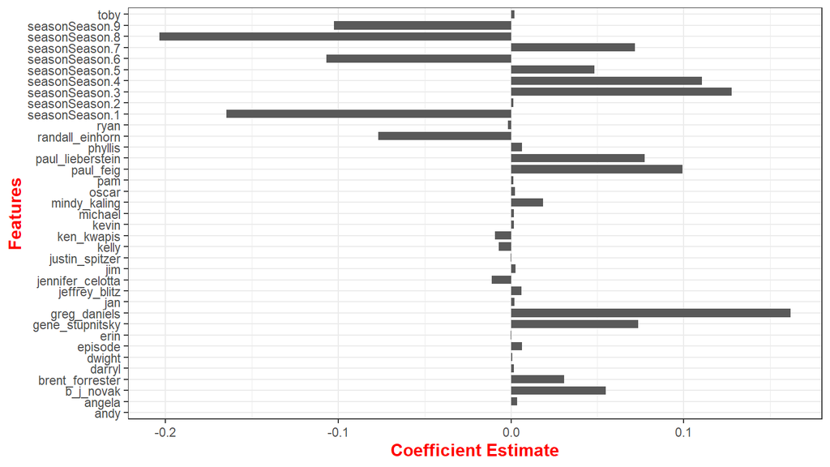

```r
p2p2_optimal_ridgem <- glmnet::glmnet(x = p2p2_pred, y = p2p2_out,
    family = "gaussian", alpha = 0, lambda = p2p2_cv_ridgem$lambda.min)
# plot
cf1 <- c()
cf2 <- c()
for (i in 1:37) {
    cf1 <- append(cf1, rownames(p2p2_optimal_ridgem$beta)[i])
    cf2 <- append(cf2, unname(p2p2_optimal_ridgem$beta)[i])
}
cf <- data.frame(cf1, cf2)

ggplot(data = cf, aes(x = cf1, y = cf2)) + geom_bar(stat = "identity",
    width = 0.75) + coord_flip() + labs(x = "Features", y = "Coefficient Estimate") +
    theme_bw() + theme(plot.title = element_text(hjust = 0.5),
    axis.title.x = element_text(face = "bold", colour = "red",
        size = 12), axis.title.y = element_text(face = "bold",
        colour = "red", size = 12))
```

I choose the suggested lambda value that minimizes the expected prediction error under the 10 fold cross validation, because from the plot, expected prediction error picks up obviously as lambda increases.

Based on the plot, the important predictors are season9, season8, season7, season6, season5, season4, season3, season1, randall_einhorn, paul_lieberstein, paul_feig, greg_daniels, and gene_stupnitsky, whereas the rest of the predictors are not.

### Part 3 (10 pts)

Finally, consider linear regression with the LASSO penalty. Using a pre-built implementation, train the model using a large number of possible values for $\lambda$.

Using $10$-fold cross validation, find a reasonable value of $\lambda$ that should minimize the expected prediction error. You can choose the actual minimum or a slightly less complex model (smaller $\lambda$ is less complex). Defend this choice.

Create a plot that demonstrates the regression coefficients for the LASSO regression with your optimal choice of $\lambda$. Which predictors are important? Which ones are not?

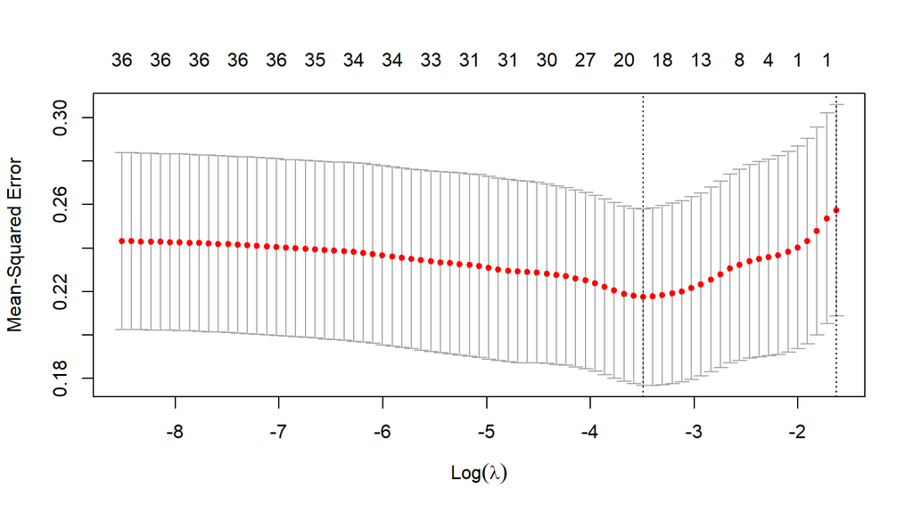

```r
p2p3_pred <- data.matrix(o_train[, -38])
p2p3_out <- data.matrix(o_train$imdb_rating)

# 100 possible values of lambda
p2p3_lassom <- glmnet(x = p2p3_pred, y = p2p3_out, family = "gaussian",
    alpha = 1, nlambda = 100)
# print(p2p3_lassom)

p2p3_cv_lassom <- cv.glmnet(x = p2p3_pred, y = p2p3_out, family = "gaussian",
    alpha = 1, nfolds = 10, type.measure = "mse")
plot(p2p3_cv_lassom)
```

```r
print(p2p3_cv_lassom)
```

```
##
## Call:  cv.glmnet(x = p2p3_pred, y = p2p3_out, type.measure = "mse",      nfolds = 10, family = "gaussian", alpha = 1)
##
## Measure: Mean-Squared Error
##
##      Lambda Index Measure      SE Nonzero
## min 0.03046    21  0.2175 0.04052      20
## 1se 0.19580     1  0.2575 0.04857       0
```

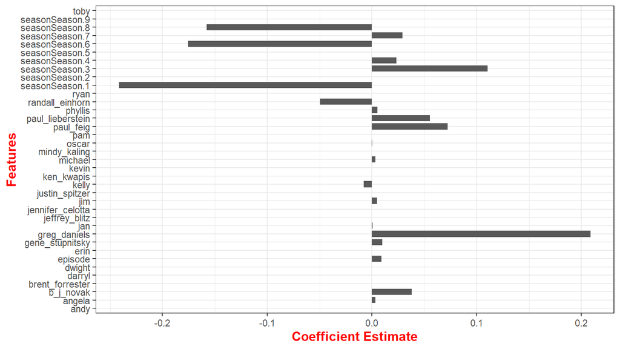

```r
# 0.03343 is the initial p2p3_cv_lassom$lambda.min we get
p2p3_optimal_lassom <- glmnet(x = p2p3_pred, y = p2p3_out, family = "gaussian",
    alpha = 1, lambda = p2p3_cv_lassom$lambda.min)
# plot
cf1 <- c()
cf2 <- c()
for (i in 1:37) {
    cf1 <- append(cf1, rownames(p2p3_optimal_lassom$beta)[i])
    cf2 <- append(cf2, unname(p2p3_optimal_lassom$beta)[i])
}
cf <- data.frame(cf1, cf2)

ggplot(data = cf, aes(x = cf1, y = cf2)) + geom_bar(stat = "identity",
    width = 0.75) + coord_flip() + labs(x = "Features", y = "Coefficient Estimate") +
    theme_bw() + theme(plot.title = element_text(hjust = 0.5),
    axis.title.x = element_text(face = "bold", colour = "red",
        size = 12), axis.title.y = element_text(face = "bold",
        colour = "red", size = 12))
```

I choose the suggested lambda value that minimizes the expected prediction error under the 10 fold cross validation, because from the plot, expected prediction error picks up obviously as lambda increases.

Based on the plot, the important predictors are season8, season6, season3, season1, paul_feig, and greg_daniels, whereas the rest of the predictors are not.

### Part 4 (5 pts)

Which of OLS with all predictors, OLS with your chosen subset of predictors, Ridge, or LASSO has the smallest cross validation estimate of expected prediction error? Do you have any intuition as to why this result occurs?

Using the optimal models from each step, compute an estimate of the expected prediction error using the heldout test data. Does the same relationship hold?

Compare your plots for the regression coefficients for the full OLS model, the ridge regression, and LASSO regression. How do LASSO and Ridge improve the expected prediction error for this problem?

```r
data.frame(epe_full_lm = lm_pred_metrics(p2p1_m), epe_subset_lm = lm_pred_metrics(p2p1_imp_pred_m),
    epe_optimal_ridge = min(p2p2_cv_ridgem$cvm), epe_optimal_lasso = min(p2p3_cv_lassom$cvm))
```

| epe_full_lm | epe_subset_lm | epe_optimal_ridge | epe_optimal_lasso |
| --- | --- | --- | --- |
| 0.2343854 | 0.2543553 | 0.203747 | 0.2175035 |

According to the above comparison, the optimal ridge and lasso models have similar performance on expected prediction errors that are both lower than the OLS models.

```r
# delete variable episode_name
o_test <- o_test %>%
    select(-episode_name)

# split variable season into 9 variables
dummy_o_test <- caret::dummyVars("~.", data = o_test)
o_test <- data.frame(predict(dummy_o_test, newdata = o_test))

p2p4_pred_mat <- as.matrix(o_test[, -38])
p2p4_pred_df_full <- o_test[, -38]
p2p4_pred_df_imp <- o_test %>%
    select(seasonSeason.3, seasonSeason.1, paul_lieberstein,
        mindy_kaling, justin_spitzer, greg_daniels, b_j_novak,
        imdb_rating)

# predictions
o_test$full_lm <- predict(p2p1_m, newdata = p2p4_pred_df_full)
o_test$subset_lm <- predict(p2p1_imp_pred_m, newdata = p2p4_pred_df_imp)
o_test$optimal_ridge <- predict(p2p2_optimal_ridgem, newx = p2p4_pred_mat)
o_test$optimal_lasso <- predict(p2p3_optimal_lassom, newx = p2p4_pred_mat)

# mse comparison
data.frame(mse_full_lm = mse(o_test$imdb_rating, o_test$full_lm),
    mse_subset_lm = mse(o_test$imdb_rating, o_test$subset_lm),
    mse_optimal_ridge = mse(o_test$imdb_rating, o_test$optimal_ridge),
    mse_optimal_lasso = mse(o_test$imdb_rating, o_test$optimal_lasso))
```

| mse_full_lm | mse_subset_lm | mse_optimal_ridge | mse_optimal_lasso |
| --- | --- | --- | --- |
| 0.2393565 | 0.1831076 | 0.1535066 | 0.1382443 |

## Problem 3: A Nifty Identity for Cubic Regression Splines (15 pts)

Regression splines are a broadly applicable method for regression analysis because they can be represented and estimated as an augmented OLS problem.

A generic cubic regression spline with $K$ knots can be represented as a linear model with $K + 4$ basis expansion terms:

$$h_1(x) = 1 \text{ ; } h_{\text{2 to
4}}(x) = \{x,x^2,x^3\}$$

$$h_{\text{5 to K + 4}} = \{(x -
\xi_1)_+^3 , (x - \xi_2)_+^3,...,(x - \xi_K)_+^3\}$$

$$y_i = \alpha + \sum \limits_{k = 2}^{K +
4} \beta_k h_k(x_i) + \epsilon_i$$
Cubic regression splines fit a function to the data that is continuous with respect to $x$ and continuous in its first two derivatives.

For an arbitrary collection of $K \le N$ knots, show that the cubic regression spline provides a function that is continuous in the first and second derivative at the knots.

Notes:

1. You can assume that the function is continuous and twice differentiable away from the knots. This is true and provable, but you can just take that for granted without further explanation.
2. With an appropriate argument about the relationship between continuity in the 1st and 2nd derivatives, you don’t need to show continuity on the first derivatives.
3. Remember that we can show continuity by proving that the left and right limits of a function are equivalent!

## Problem 3 solution:

$$\begin{eqnarray}
y_i &=& \alpha + \beta_2 h_2(x_i) + \beta_3 h_3(x_i) + \beta_4
h_4(x_i) + \sum \limits_{k = 5}^{K} \beta_k h_k(x_i) + \epsilon_i\\
y_i &=& \alpha + \beta_2x_i + \beta_3 x_i^2 + \beta_4 x_i^3
+ \sum \limits_{k = 1}^{K} \beta_{k+4} (x_i - \xi_k)^3 + \epsilon_i\\
\frac{dy_i}{dx_i} &=& \beta_2 + 2\beta_3x_i + 3\beta_4 x_i^2 +
3\sum \limits_{k = 1}^{K} \beta_{k+4} (x_i - \xi_k)^2\\
\frac{d^2y_i}{dx_i^2} &=& 2\beta_3 + 6\beta_4 x_i + 6\sum
\limits_{k = 1}^{K} \beta_{k+4} (x_i - \xi_k)\\
\frac{d^3y_i}{dx_i^3} &=& 6\beta_4 + 6\sum \limits_{k = 1}^{K}
\beta_{k+4}\\
\end{eqnarray}$$
Since the function is three-times differentiable, the second derivative of the function is continuous. Since the function has a second derivative, it’s twice differentiable, which proves that the function’s first derivative is continuous. Since the function is continuous in the first and second derivative for all $x_i$, the function is continuous in the first and second derivative at the knots.

## Problem 4: Nonlinear Regression Methods (35 pts)

### Part 1 (10 pts)

Let’s start by looking at a single predictor - the student/faculty ratio `S.F.Ratio`. Plot log out of state tuition against the student/faculty ratio. Does this look linear?

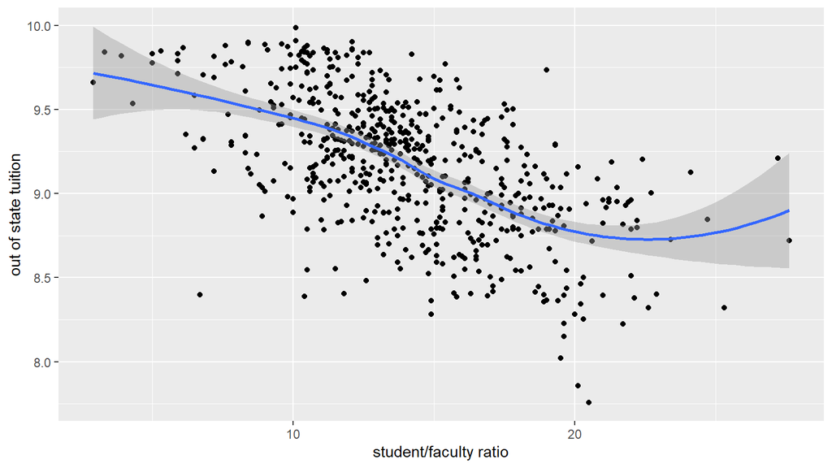

```r
# initial recoding: use c_train_q4 moving on for
# consistence
c_train_q4 <- c_train
c_train_q4$Outstate <- log(c_train$Outstate)

approachPlot <- qplot(x = S.F.Ratio, y = Outstate, data = c_train_q4,
    geom = c("point", "smooth"), ylab = "out of state tuition",
    xlab = "student/faculty ratio")
approachPlot
```

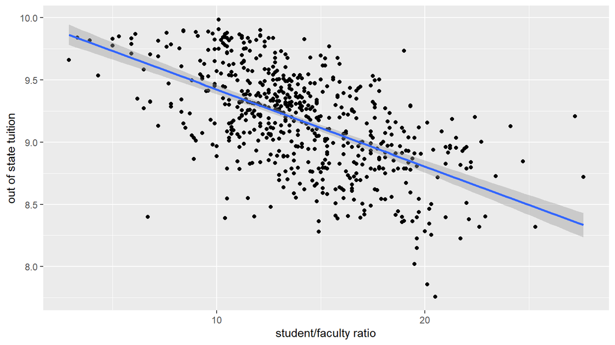

```r
# It looks quite linear, but could also be a second/third
# degree polynomial relationship. Compare the first smooth
# graph with the second one plotting in linear model, we
# can see that the relationship has a linear trend.
lmApprochPlot <- qplot(x = S.F.Ratio, y = Outstate, data = c_train_q4,
    geom = c("point", "smooth"), method = "lm", ylab = "out of state tuition",
    xlab = "student/faculty ratio")
lmApprochPlot
```

Using a measure of expected prediction error appropriate for a standard linear model, find the order of global polynomial that minimizes EPE. Be sure to note your choice and why you made it. Using this value, train your model on the full training set and plot the prediction curve implied by the polynomial model on your graph.

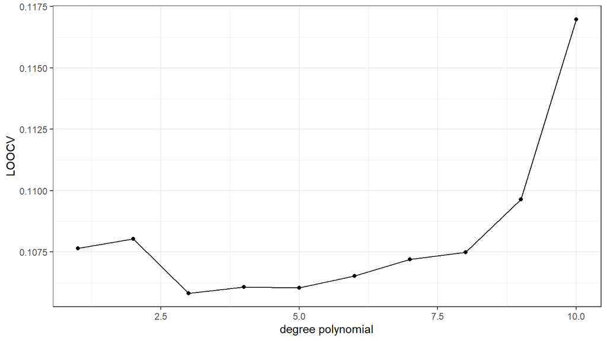

```r
# we reuse the function from problem set 2 for the wealth
# of non-simulation based estimates of the expected
# prediction error to make this decision
lm_pred_metrics <- function(fit_model) {

    # log-likelihood
    N <- length(fit_model$residuals)
    sig <- sigma(fit_model)
    res <- fit_model$residuals
    ll <- -N/2 * log10(2 * pi) - N/2 * log10(sig^2) - 1/(2 *
        sig^2) * sum(res^2)

    # AIC
    d <- length(fit_model$coefficients) + 1
    AIC <- -2 * ll + 2 * (d)

    # BIC
    BIC <- -2 * ll + d * log10(N)

    # LOOCV
    LOOCV <- (res[1]/(1 - hatvalues(fit_model)[1]))^2
    if (N >= 2) {
        for (i in 2:N) {
            LOOCV <- LOOCV + (res[i]/(1 - hatvalues(fit_model)[i]))^2
        }
    }
    LOOCV_final <- LOOCV/N

    return(c(AIC = AIC, BIC = BIC, LOOCV = LOOCV_final))
}

p4p1_model_1 <- lm(c_train_q4$Outstate ~ poly(c_train_q4$S.F.Ratio,
    1))
p4p1_model_2 <- lm(c_train_q4$Outstate ~ poly(c_train_q4$S.F.Ratio,
    2))
p4p1_model_3 <- lm(c_train_q4$Outstate ~ poly(c_train_q4$S.F.Ratio,
    3))
p4p1_model_4 <- lm(c_train_q4$Outstate ~ poly(c_train_q4$S.F.Ratio,
    4))
p4p1_model_5 <- lm(c_train_q4$Outstate ~ poly(c_train_q4$S.F.Ratio,
    5))
p4p1_model_6 <- lm(c_train_q4$Outstate ~ poly(c_train_q4$S.F.Ratio,
    6))
p4p1_model_7 <- lm(c_train_q4$Outstate ~ poly(c_train_q4$S.F.Ratio,
    7))
p4p1_model_8 <- lm(c_train_q4$Outstate ~ poly(c_train_q4$S.F.Ratio,
    8))
p4p1_model_9 <- lm(c_train_q4$Outstate ~ poly(c_train_q4$S.F.Ratio,
    9))
p4p1_model_10 <- lm(c_train_q4$Outstate ~ poly(c_train_q4$S.F.Ratio,
    10))

p4p1_df <- t(cbind(lm_pred_metrics(p4p1_model_1), lm_pred_metrics(p4p1_model_2),
    lm_pred_metrics(p4p1_model_3), lm_pred_metrics(p4p1_model_4),
    lm_pred_metrics(p4p1_model_5), lm_pred_metrics(p4p1_model_6),
    lm_pred_metrics(p4p1_model_7), lm_pred_metrics(p4p1_model_8),
    lm_pred_metrics(p4p1_model_9), lm_pred_metrics(p4p1_model_10)))
num <- c(1:10)
p4p1_df <- data.frame(num, p4p1_df)
# plot LOOCV for various degree of polynomial
ggplot(data = p4p1_df) + geom_point(aes(x = num, y = LOOCV.1)) +
    geom_line(aes(x = num, y = LOOCV.1)) + xlab("degree polynomial") +
    ylab("LOOCV") + theme_bw()
```

```r
# We use LOOCV as our measure of EPE and find that third
# order of global polynomial that minimizes EPE. We choose
# LOOCV as there is less worry about bias and variance than
# other approaches and it's asymptotically unbiased for the
# the EPE.From the graph above, we could see that the LOOCV
# reaches minimum for degree polynomial=3.
```

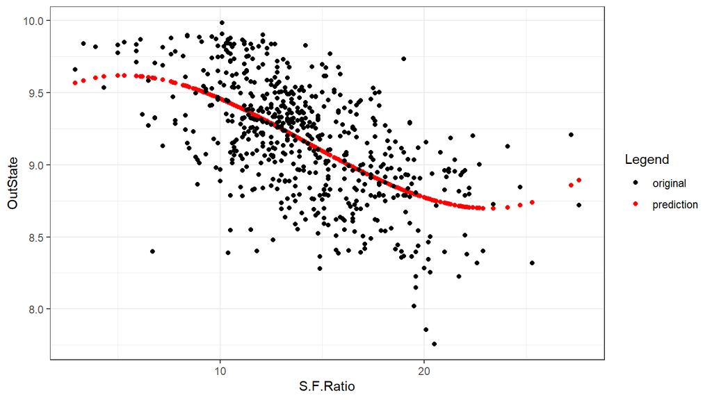

```r
# optimal polynomial model train the model with third
# degree of polynomial
optimalPolyModel <- lm(data = c_train_q4, Outstate ~ poly(S.F.Ratio,
    3))
polyPredResult <- data.frame(S.F.Ratio = c_train_q4$S.F.Ratio,
    predOutState = optimalPolyModel$fitted.values, originalOutState = c_train_q4$Outstate)

# plot our polynomial model
polyPredResultPlot <- ggplot(data = polyPredResult) + geom_point(aes(x = S.F.Ratio,
    y = predOutState, col = "prediction")) + geom_point(aes(x = S.F.Ratio,
    y = originalOutState, col = "original")) + scale_colour_manual(name = "Legend",
    values = c("black", "red")) + ylab("OutState") + theme_bw()
polyPredResultPlot
```

Next, estimate a cubic natural spline and a smoothing spline using the entire training data. For the natural spline, you need to choose the number of knots or degrees of freedom. I would recommend setting these to 5 to start and playing with it until you get something that looks right. For the smoothing spline, you should choose the final form using a built-in cross-validation method (most likely GCV). Add the prediction curve to your plot. How do the drawn curves differ between methods?

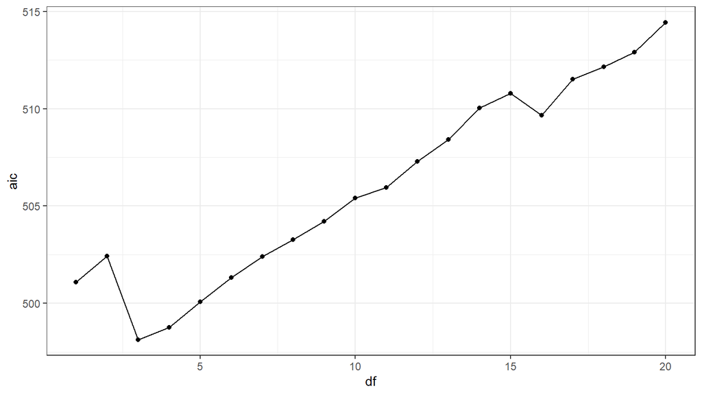

```r
# natural spline(cubic) find the optimal df with our
# measure of EPE
p4_1_num <- seq(1, 20, 1)
p4_1_aic <- c()
p4_1_bic <- c()
p4_1_loocv <- c()

for (i in 1:20) {
    cubicSpline <- lm(Outstate ~ ns(S.F.Ratio, df = i), data = c_train_q4)
    tempCheck <- unname(lm_pred_metrics(cubicSpline))

    p4_1_aic <- append(p4_1_aic, tempCheck[1])
    p4_1_bic <- append(p4_1_bic, tempCheck[2])
    p4_1_loocv <- append(p4_1_loocv, tempCheck[3])
}
p4_1_dat <- data.frame(p4_1_num, p4_1_aic, p4_1_bic, p4_1_loocv)

# plot how each df perform with each measure of EPE
ggplot(data = p4_1_dat) + geom_point(aes(x = p4_1_num, y = p4_1_aic)) +
    geom_line(aes(x = p4_1_num, y = p4_1_aic)) + xlab("df") +
    ylab("aic") + theme_bw()
```

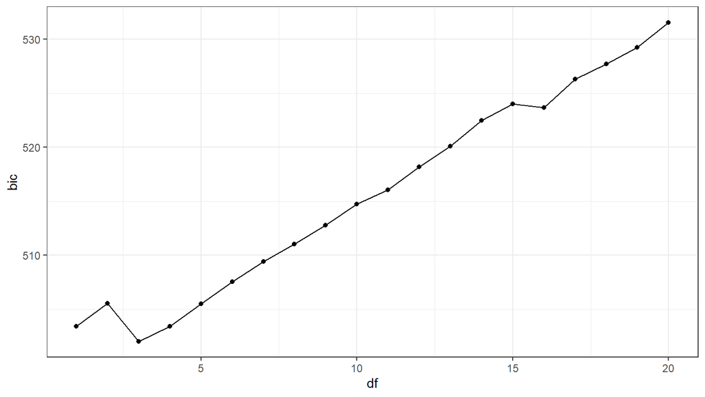

```r
ggplot(data = p4_1_dat) + geom_point(aes(x = p4_1_num, y = p4_1_bic)) +
    geom_line(aes(x = p4_1_num, y = p4_1_bic)) + xlab("df") +
    ylab("bic") + theme_bw()
```